# MTH6139 Time Series

Coursework 1

School of Mathematical Sciences

March 2024

```
## Disabling weekly seasonality. Run prophet with weekly.seasonality=TRUE to override this.
```

```
## Disabling daily seasonality. Run prophet with daily.seasonality=TRUE to override this.
```

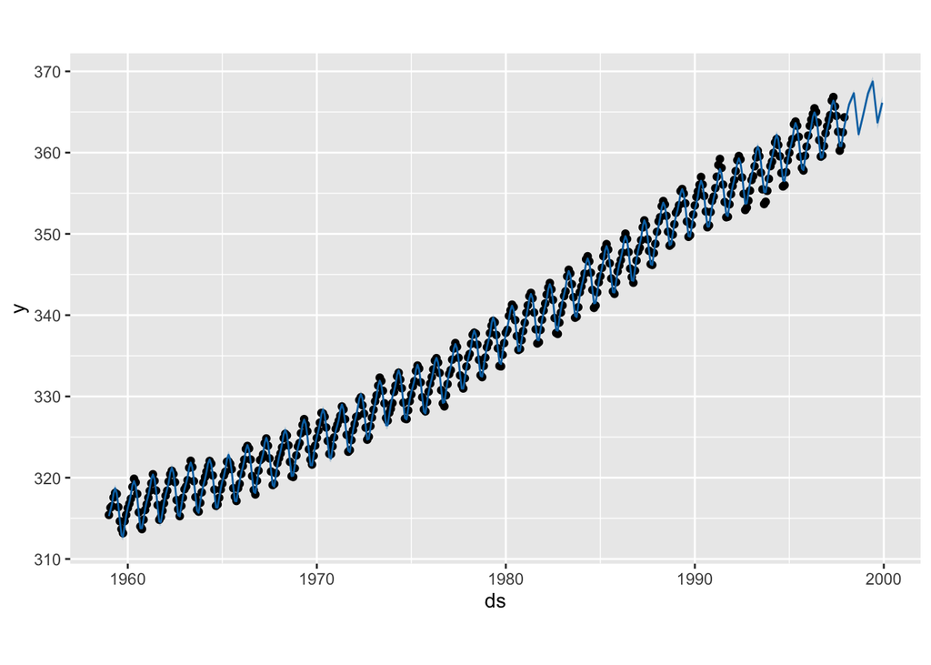

```
##        ds             y
##  Min.   :1959   Min.   :313.2
##  1st Qu.:1969   1st Qu.:323.5
##  Median :1978   Median :335.2
##  Mean   :1978   Mean   :337.1
##  3rd Qu.:1988   3rd Qu.:350.3
##  Max.   :1998   Max.   :366.8
```

```
##         ds      y
## 1 Jan 1959 315.42
## 2 Feb 1959 316.31
## 3 Mar 1959 316.50
## 4 Apr 1959 317.56
## 5 May 1959 318.13
## 6 Jun 1959 318.00
```

```
##           ds      y
## 463 Jul 1997 364.52
## 464 Aug 1997 362.57
## 465 Sep 1997 360.24
## 466 Oct 1997 360.83
## 467 Nov 1997 362.49
## 468 Dec 1997 364.34
```

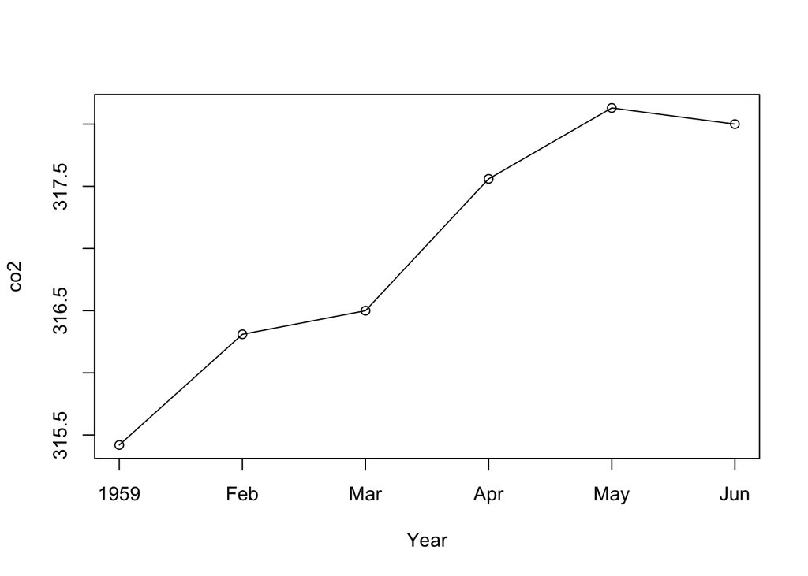

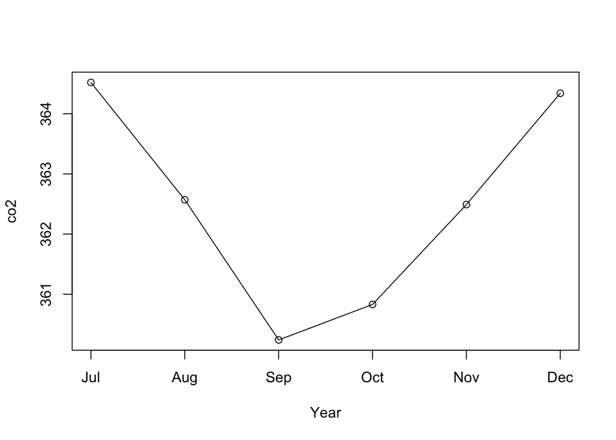

Description of co2: Atmospheric concentrations of CO2 are expressed in parts per million (ppm) and reported in the preliminary 1997 SIO manometric mole fraction scale.

Format: A time series of 468 observations; monthly from 1959 to 1997.

References: Cleveland, W. S. (1993) Visualizing Data. New Jersey: Summit Press.

The purpose of the project is to see how the concentration of co2 change with time.

It can be seen that there is an upward trend which shows that the concentration of carbon dioxide is rising between year 1959 and year 2000. The y-axis of the graph shows the concentration of co2 with data between 310 and 370, x-axis shows the time of year. The graph also shows that there is fluctuations through out the 40 year time which indicates that the concentration of co2 changes with seasons, this means it shows seasonality with the data.